# Risk Factor Analysis

## Outcome Variable

**Outcome Variable:** wasted

## Predictor Variables

**Intervention Variable:** mhtcm

**Adjustment Set:**

unadjusted

## Stratifying Variables

The analysis was stratified on these variable(s):

- agecat
- studyid
- country

## Data Summary

| agecat | studyid | country | mhtcm | wasted | n_cell | n | outcome_variable |
| --- | --- | --- | --- | --- | --- | --- | --- |
| Birth | ki0047075b-MAL-ED | BANGLADESH | >=155 cm | 0 | 19 | 209 | wasted |
| Birth | ki0047075b-MAL-ED | BANGLADESH | >=155 cm | 1 | 2 | 209 | wasted |
| Birth | ki0047075b-MAL-ED | BANGLADESH | <151 cm | 0 | 111 | 209 | wasted |
| Birth | ki0047075b-MAL-ED | BANGLADESH | <151 cm | 1 | 23 | 209 | wasted |
| Birth | ki0047075b-MAL-ED | BANGLADESH | [151-155) cm | 0 | 44 | 209 | wasted |
| Birth | ki0047075b-MAL-ED | BANGLADESH | [151-155) cm | 1 | 10 | 209 | wasted |
| Birth | ki0047075b-MAL-ED | BRAZIL | >=155 cm | 0 | 31 | 61 | wasted |
| Birth | ki0047075b-MAL-ED | BRAZIL | >=155 cm | 1 | 1 | 61 | wasted |
| Birth | ki0047075b-MAL-ED | BRAZIL | <151 cm | 0 | 18 | 61 | wasted |
| Birth | ki0047075b-MAL-ED | BRAZIL | <151 cm | 1 | 1 | 61 | wasted |
| Birth | ki0047075b-MAL-ED | BRAZIL | [151-155) cm | 0 | 10 | 61 | wasted |
| Birth | ki0047075b-MAL-ED | BRAZIL | [151-155) cm | 1 | 0 | 61 | wasted |
| Birth | ki0047075b-MAL-ED | INDIA | >=155 cm | 0 | 9 | 41 | wasted |
| Birth | ki0047075b-MAL-ED | INDIA | >=155 cm | 1 | 2 | 41 | wasted |
| Birth | ki0047075b-MAL-ED | INDIA | <151 cm | 0 | 16 | 41 | wasted |
| Birth | ki0047075b-MAL-ED | INDIA | <151 cm | 1 | 3 | 41 | wasted |
| Birth | ki0047075b-MAL-ED | INDIA | [151-155) cm | 0 | 11 | 41 | wasted |
| Birth | ki0047075b-MAL-ED | INDIA | [151-155) cm | 1 | 0 | 41 | wasted |
| Birth | ki0047075b-MAL-ED | NEPAL | >=155 cm | 0 | 6 | 26 | wasted |
| Birth | ki0047075b-MAL-ED | NEPAL | >=155 cm | 1 | 0 | 26 | wasted |
| Birth | ki0047075b-MAL-ED | NEPAL | <151 cm | 0 | 11 | 26 | wasted |
| Birth | ki0047075b-MAL-ED | NEPAL | <151 cm | 1 | 2 | 26 | wasted |
| Birth | ki0047075b-MAL-ED | NEPAL | [151-155) cm | 0 | 7 | 26 | wasted |
| Birth | ki0047075b-MAL-ED | NEPAL | [151-155) cm | 1 | 0 | 26 | wasted |
| Birth | ki0047075b-MAL-ED | PERU | >=155 cm | 0 | 46 | 221 | wasted |
| Birth | ki0047075b-MAL-ED | PERU | >=155 cm | 1 | 1 | 221 | wasted |
| Birth | ki0047075b-MAL-ED | PERU | <151 cm | 0 | 123 | 221 | wasted |
| Birth | ki0047075b-MAL-ED | PERU | <151 cm | 1 | 4 | 221 | wasted |
| Birth | ki0047075b-MAL-ED | PERU | [151-155) cm | 0 | 47 | 221 | wasted |
| Birth | ki0047075b-MAL-ED | PERU | [151-155) cm | 1 | 0 | 221 | wasted |

[output cut: 324 more lines]

The following strata were considered:

- agecat: 24 months, studyid: ki0047075b-MAL-ED, country: BANGLADESH
- agecat: 24 months, studyid: ki0047075b-MAL-ED, country: BRAZIL
- agecat: 24 months, studyid: ki0047075b-MAL-ED, country: INDIA
- agecat: 24 months, studyid: ki0047075b-MAL-ED, country: NEPAL
- agecat: 24 months, studyid: ki0047075b-MAL-ED, country: PERU
- agecat: 24 months, studyid: ki0047075b-MAL-ED, country: SOUTH AFRICA
- agecat: 24 months, studyid: ki0047075b-MAL-ED, country: TANZANIA, UNITED REPUBLIC OF
- agecat: 24 months, studyid: ki1017093-NIH-Birth, country: BANGLADESH
- agecat: 24 months, studyid: ki1017093b-PROVIDE, country: BANGLADESH
- agecat: 24 months, studyid: ki1017093c-NIH-Crypto, country: BANGLADESH
- agecat: 24 months, studyid: ki1066203-TanzaniaChild2, country: TANZANIA, UNITED REPUBLIC OF
- agecat: 24 months, studyid: ki1101329-Keneba, country: GAMBIA
- agecat: 24 months, studyid: ki1119695-PROBIT, country: BELARUS
- agecat: 24 months, studyid: ki1126311-ZVITAMBO, country: ZIMBABWE
- agecat: 24 months, studyid: ki1135781-COHORTS, country: GUATEMALA
- agecat: 24 months, studyid: ki1135781-COHORTS, country: INDIA
- agecat: 24 months, studyid: ki1135781-COHORTS, country: PHILIPPINES
- agecat: 24 months, studyid: ki1148112-LCNI-5, country: MALAWI
- agecat: 24 months, studyid: kiGH5241-JiVitA-3, country: BANGLADESH
- agecat: 6 months, studyid: ki0047075b-MAL-ED, country: BANGLADESH
- agecat: 6 months, studyid: ki0047075b-MAL-ED, country: BRAZIL
- agecat: 6 months, studyid: ki0047075b-MAL-ED, country: INDIA
- agecat: 6 months, studyid: ki0047075b-MAL-ED, country: NEPAL
- agecat: 6 months, studyid: ki0047075b-MAL-ED, country: PERU
- agecat: 6 months, studyid: ki0047075b-MAL-ED, country: SOUTH AFRICA
- agecat: 6 months, studyid: ki0047075b-MAL-ED, country: TANZANIA, UNITED REPUBLIC OF
- agecat: 6 months, studyid: ki1000304b-SAS-CompFeed, country: INDIA
- agecat: 6 months, studyid: ki1000304b-SAS-FoodSuppl, country: INDIA
- agecat: 6 months, studyid: ki1017093-NIH-Birth, country: BANGLADESH
- agecat: 6 months, studyid: ki1017093b-PROVIDE, country: BANGLADESH
- agecat: 6 months, studyid: ki1017093c-NIH-Crypto, country: BANGLADESH
- agecat: 6 months, studyid: ki1066203-TanzaniaChild2, country: TANZANIA, UNITED REPUBLIC OF
- agecat: 6 months, studyid: ki1101329-Keneba, country: GAMBIA
- agecat: 6 months, studyid: ki1112895-Guatemala BSC, country: GUATEMALA
- agecat: 6 months, studyid: ki1119695-PROBIT, country: BELARUS
- agecat: 6 months, studyid: ki1126311-ZVITAMBO, country: ZIMBABWE
- agecat: 6 months, studyid: ki1135781-COHORTS, country: GUATEMALA
- agecat: 6 months, studyid: ki1135781-COHORTS, country: INDIA
- agecat: 6 months, studyid: ki1135781-COHORTS, country: PHILIPPINES
- agecat: 6 months, studyid: ki1148112-LCNI-5, country: MALAWI
- agecat: 6 months, studyid: kiGH5241-JiVitA-3, country: BANGLADESH
- agecat: Birth, studyid: ki0047075b-MAL-ED, country: BANGLADESH
- agecat: Birth, studyid: ki0047075b-MAL-ED, country: BRAZIL
- agecat: Birth, studyid: ki0047075b-MAL-ED, country: INDIA
- agecat: Birth, studyid: ki0047075b-MAL-ED, country: NEPAL
- agecat: Birth, studyid: ki0047075b-MAL-ED, country: PERU
- agecat: Birth, studyid: ki0047075b-MAL-ED, country: SOUTH AFRICA
- agecat: Birth, studyid: ki0047075b-MAL-ED, country: TANZANIA, UNITED REPUBLIC OF
- agecat: Birth, studyid: ki1000304b-SAS-CompFeed, country: INDIA
- agecat: Birth, studyid: ki1017093-NIH-Birth, country: BANGLADESH
- agecat: Birth, studyid: ki1017093b-PROVIDE, country: BANGLADESH
- agecat: Birth, studyid: ki1017093c-NIH-Crypto, country: BANGLADESH
- agecat: Birth, studyid: ki1101329-Keneba, country: GAMBIA
- agecat: Birth, studyid: ki1119695-PROBIT, country: BELARUS
- agecat: Birth, studyid: ki1126311-ZVITAMBO, country: ZIMBABWE
- agecat: Birth, studyid: ki1135781-COHORTS, country: GUATEMALA
- agecat: Birth, studyid: ki1135781-COHORTS, country: INDIA
- agecat: Birth, studyid: ki1135781-COHORTS, country: PHILIPPINES
- agecat: Birth, studyid: kiGH5241-JiVitA-3, country: BANGLADESH

### Dropped Strata

Some strata were dropped due to rare outcomes:

- agecat: Birth, studyid: ki0047075b-MAL-ED, country: BANGLADESH
- agecat: Birth, studyid: ki0047075b-MAL-ED, country: BRAZIL
- agecat: Birth, studyid: ki0047075b-MAL-ED, country: INDIA
- agecat: Birth, studyid: ki0047075b-MAL-ED, country: NEPAL
- agecat: Birth, studyid: ki0047075b-MAL-ED, country: PERU
- agecat: Birth, studyid: ki0047075b-MAL-ED, country: SOUTH AFRICA
- agecat: Birth, studyid: ki0047075b-MAL-ED, country: TANZANIA, UNITED REPUBLIC OF
- agecat: 6 months, studyid: ki0047075b-MAL-ED, country: BANGLADESH
- agecat: 6 months, studyid: ki0047075b-MAL-ED, country: BRAZIL
- agecat: 6 months, studyid: ki0047075b-MAL-ED, country: NEPAL
- agecat: 6 months, studyid: ki0047075b-MAL-ED, country: PERU
- agecat: 6 months, studyid: ki0047075b-MAL-ED, country: SOUTH AFRICA
- agecat: 6 months, studyid: ki0047075b-MAL-ED, country: TANZANIA, UNITED REPUBLIC OF
- agecat: 6 months, studyid: ki1017093c-NIH-Crypto, country: BANGLADESH
- agecat: 6 months, studyid: ki1112895-Guatemala BSC, country: GUATEMALA
- agecat: 6 months, studyid: ki1119695-PROBIT, country: BELARUS
- agecat: 6 months, studyid: ki1135781-COHORTS, country: GUATEMALA
- agecat: 6 months, studyid: ki1148112-LCNI-5, country: MALAWI
- agecat: 24 months, studyid: ki0047075b-MAL-ED, country: BANGLADESH
- agecat: 24 months, studyid: ki0047075b-MAL-ED, country: BRAZIL
- agecat: 24 months, studyid: ki0047075b-MAL-ED, country: INDIA
- agecat: 24 months, studyid: ki0047075b-MAL-ED, country: NEPAL
- agecat: 24 months, studyid: ki0047075b-MAL-ED, country: PERU
- agecat: 24 months, studyid: ki0047075b-MAL-ED, country: SOUTH AFRICA
- agecat: 24 months, studyid: ki0047075b-MAL-ED, country: TANZANIA, UNITED REPUBLIC OF
- agecat: 24 months, studyid: ki1066203-TanzaniaChild2, country: TANZANIA, UNITED REPUBLIC OF
- agecat: 24 months, studyid: ki1119695-PROBIT, country: BELARUS
- agecat: 24 months, studyid: ki1148112-LCNI-5, country: MALAWI

## Methods Detail

We’re interested in the causal parameters $E[Y_a]$ for all values of $a \in \mathcal{A}$. These parameters represent the mean outcome if, possibly contrary to fact, we intervened to set all units to have $A=a$. Under the randomization and positivity assumptions, these are identified by the statistical parameters $\psi_a=E_W[E_{Y|A,W}(Y|A=a,W)]$. In addition, we’re interested in the mean of $Y$, $E[Y]$ under no intervention (the observed mean). We will estimate these parameters by using SuperLearner to fit the relevant likelihood factors – $E_{Y|A,W}(Y|A=a,W)$ and $p(A=a|W)$, and then updating our likelihood fit using a joint TMLE.

For unadjusted analyses ($W=\{\}$), initial likelihoods were estimated using Lrnr_glm to estimate the simple $E(Y|A)$ and Lrnr_mean to estimate $p(A)$. For adjusted analyses, a small library containing Lrnr_glmnet, Lrnr_xgboost, and Lrnr_mean was used.

Having estimated these parameters, we will then use the delta method to estimate relative risks and attributable risks relative to a prespecified baseline level of $A$.

# Results Detail

## Results Plots

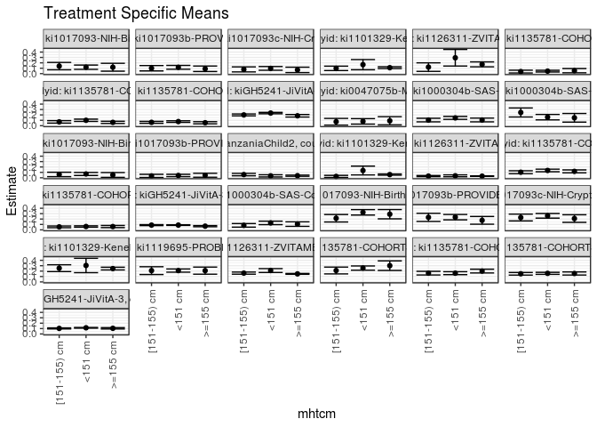

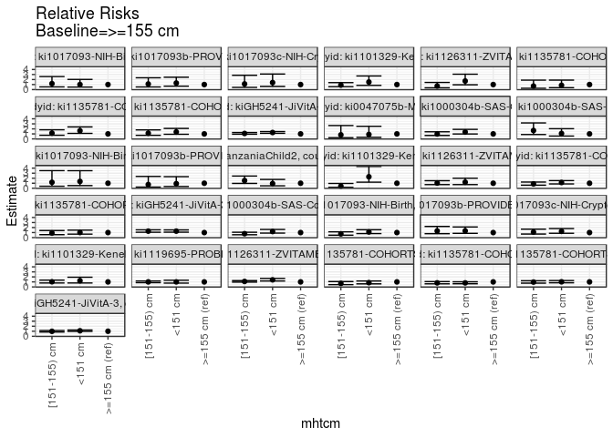

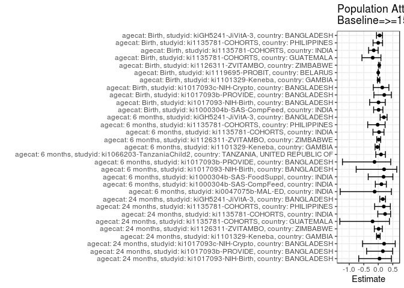

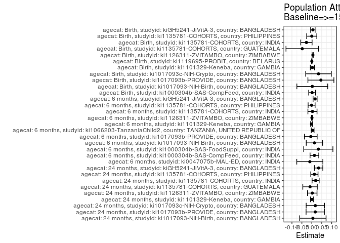

## Results Table

### Parameter: TSM

| agecat | studyid | country | intervention_level | baseline_level | estimate | ci_lower | ci_upper |
| --- | --- | --- | --- | --- | --- | --- | --- |
| Birth | ki1000304b-SAS-CompFeed | INDIA | >=155 cm | NA | 0.1064815 | 0.0647800 | 0.1481829 |
| Birth | ki1000304b-SAS-CompFeed | INDIA | <151 cm | NA | 0.1285266 | 0.0959775 | 0.1610758 |
| Birth | ki1000304b-SAS-CompFeed | INDIA | [151-155) cm | NA | 0.0829876 | 0.0497191 | 0.1162560 |
| Birth | ki1017093-NIH-Birth | BANGLADESH | >=155 cm | NA | 0.2897196 | 0.2036920 | 0.3757473 |
| Birth | ki1017093-NIH-Birth | BANGLADESH | <151 cm | NA | 0.3243243 | 0.2740017 | 0.3746469 |
| Birth | ki1017093-NIH-Birth | BANGLADESH | [151-155) cm | NA | 0.2148148 | 0.1454759 | 0.2841538 |
| Birth | ki1017093b-PROVIDE | BANGLADESH | >=155 cm | NA | 0.1759259 | 0.1040455 | 0.2478063 |
| Birth | ki1017093b-PROVIDE | BANGLADESH | <151 cm | NA | 0.2348754 | 0.1852612 | 0.2844896 |
| Birth | ki1017093b-PROVIDE | BANGLADESH | [151-155) cm | NA | 0.2314050 | 0.1561878 | 0.3066221 |
| Birth | ki1017093c-NIH-Crypto | BANGLADESH | >=155 cm | NA | 0.2093023 | 0.1390511 | 0.2795536 |
| Birth | ki1017093c-NIH-Crypto | BANGLADESH | <151 cm | NA | 0.2599010 | 0.2171038 | 0.3026982 |
| Birth | ki1017093c-NIH-Crypto | BANGLADESH | [151-155) cm | NA | 0.2280702 | 0.1651367 | 0.2910037 |
| Birth | ki1101329-Keneba | GAMBIA | >=155 cm | NA | 0.2466960 | 0.2216075 | 0.2717846 |
| Birth | ki1101329-Keneba | GAMBIA | <151 cm | NA | 0.3043478 | 0.1713300 | 0.4373657 |
| Birth | ki1101329-Keneba | GAMBIA | [151-155) cm | NA | 0.2541436 | 0.1906931 | 0.3175942 |
| Birth | ki1119695-PROBIT | BELARUS | >=155 cm | NA | 0.2086090 | 0.1428683 | 0.2743497 |
| Birth | ki1119695-PROBIT | BELARUS | <151 cm | NA | 0.2096774 | 0.1796857 | 0.2396691 |
| Birth | ki1119695-PROBIT | BELARUS | [151-155) cm | NA | 0.2090680 | 0.1366772 | 0.2814588 |
| Birth | ki1126311-ZVITAMBO | ZIMBABWE | >=155 cm | NA | 0.1488423 | 0.1406522 | 0.1570325 |
| Birth | ki1126311-ZVITAMBO | ZIMBABWE | <151 cm | NA | 0.2104208 | 0.1746554 | 0.2461863 |
| Birth | ki1126311-ZVITAMBO | ZIMBABWE | [151-155) cm | NA | 0.1624521 | 0.1424381 | 0.1824661 |
| Birth | ki1135781-COHORTS | GUATEMALA | >=155 cm | NA | 0.3009709 | 0.2123309 | 0.3896109 |
| Birth | ki1135781-COHORTS | GUATEMALA | <151 cm | NA | 0.2561983 | 0.2172819 | 0.2951147 |
| Birth | ki1135781-COHORTS | GUATEMALA | [151-155) cm | NA | 0.2111801 | 0.1480929 | 0.2742673 |
| Birth | ki1135781-COHORTS | INDIA | >=155 cm | NA | 0.2007874 | 0.1659420 | 0.2356328 |
| Birth | ki1135781-COHORTS | INDIA | <151 cm | NA | 0.1615169 | 0.1344777 | 0.1885561 |
| Birth | ki1135781-COHORTS | INDIA | [151-155) cm | NA | 0.1622807 | 0.1284292 | 0.1961322 |
| Birth | ki1135781-COHORTS | PHILIPPINES | >=155 cm | NA | 0.1558442 | 0.1271965 | 0.1844918 |
| Birth | ki1135781-COHORTS | PHILIPPINES | <151 cm | NA | 0.1584775 | 0.1396451 | 0.1773099 |
| Birth | ki1135781-COHORTS | PHILIPPINES | [151-155) cm | NA | 0.1503580 | 0.1261543 | 0.1745617 |

[output cut: 63 more lines]

### Parameter: E(Y)

| agecat | studyid | country | intervention_level | baseline_level | estimate | ci_lower | ci_upper |
| --- | --- | --- | --- | --- | --- | --- | --- |
| Birth | ki1000304b-SAS-CompFeed | INDIA | NA | NA | 0.1078629 | 0.0749278 | 0.1407980 |
| Birth | ki1017093-NIH-Birth | BANGLADESH | NA | NA | 0.2921739 | 0.2549711 | 0.3293768 |
| Birth | ki1017093b-PROVIDE | BANGLADESH | NA | NA | 0.2215686 | 0.1854897 | 0.2576475 |
| Birth | ki1017093c-NIH-Crypto | BANGLADESH | NA | NA | 0.2428977 | 0.2111977 | 0.2745977 |
| Birth | ki1101329-Keneba | GAMBIA | NA | NA | 0.2496329 | 0.2266393 | 0.2726265 |
| Birth | ki1119695-PROBIT | BELARUS | NA | NA | 0.2086320 | 0.1431813 | 0.2740828 |
| Birth | ki1126311-ZVITAMBO | ZIMBABWE | NA | NA | 0.1541943 | 0.1467576 | 0.1616309 |
| Birth | ki1135781-COHORTS | GUATEMALA | NA | NA | 0.2526738 | 0.2215120 | 0.2838356 |
| Birth | ki1135781-COHORTS | INDIA | NA | NA | 0.1736277 | 0.1554877 | 0.1917677 |
| Birth | ki1135781-COHORTS | PHILIPPINES | NA | NA | 0.1555709 | 0.1423748 | 0.1687670 |
| Birth | kiGH5241-JiVitA-3 | BANGLADESH | NA | NA | 0.1097235 | 0.1045842 | 0.1148627 |
| 6 months | ki0047075b-MAL-ED | INDIA | NA | NA | 0.0808511 | 0.0459229 | 0.1157792 |
| 6 months | ki1000304b-SAS-CompFeed | INDIA | NA | NA | 0.1190865 | 0.0945854 | 0.1435876 |
| 6 months | ki1000304b-SAS-FoodSuppl | INDIA | NA | NA | 0.1794195 | 0.1407385 | 0.2181005 |
| 6 months | ki1017093-NIH-Birth | BANGLADESH | NA | NA | 0.0651769 | 0.0442802 | 0.0860736 |
| 6 months | ki1017093b-PROVIDE | BANGLADESH | NA | NA | 0.0415282 | 0.0255778 | 0.0574787 |
| 6 months | ki1066203-TanzaniaChild2 | TANZANIA, UNITED REPUBLIC OF | NA | NA | 0.0426065 | 0.0337417 | 0.0514713 |
| 6 months | ki1101329-Keneba | GAMBIA | NA | NA | 0.0570059 | 0.0465142 | 0.0674976 |
| 6 months | ki1126311-ZVITAMBO | ZIMBABWE | NA | NA | 0.0306740 | 0.0267100 | 0.0346380 |
| 6 months | ki1135781-COHORTS | INDIA | NA | NA | 0.1214953 | 0.1064776 | 0.1365130 |
| 6 months | ki1135781-COHORTS | PHILIPPINES | NA | NA | 0.0594974 | 0.0505830 | 0.0684118 |
| 6 months | kiGH5241-JiVitA-3 | BANGLADESH | NA | NA | 0.0845584 | 0.0797428 | 0.0893740 |
| 24 months | ki1017093-NIH-Birth | BANGLADESH | NA | NA | 0.1238318 | 0.0925894 | 0.1550741 |
| 24 months | ki1017093b-PROVIDE | BANGLADESH | NA | NA | 0.1072664 | 0.0820169 | 0.1325160 |
| 24 months | ki1017093c-NIH-Crypto | BANGLADESH | NA | NA | 0.0875486 | 0.0630907 | 0.1120065 |
| 24 months | ki1101329-Keneba | GAMBIA | NA | NA | 0.1110418 | 0.0956567 | 0.1264269 |
| 24 months | ki1126311-ZVITAMBO | ZIMBABWE | NA | NA | 0.1743869 | 0.1355135 | 0.2132603 |
| 24 months | ki1135781-COHORTS | GUATEMALA | NA | NA | 0.0457256 | 0.0328110 | 0.0586403 |
| 24 months | ki1135781-COHORTS | INDIA | NA | NA | 0.0809762 | 0.0683807 | 0.0935716 |
| 24 months | ki1135781-COHORTS | PHILIPPINES | NA | NA | 0.0681911 | 0.0582056 | 0.0781766 |
| 24 months | kiGH5241-JiVitA-3 | BANGLADESH | NA | NA | 0.2179697 | 0.2080911 | 0.2278482 |

### Parameter: RR

| agecat | studyid | country | intervention_level | baseline_level | estimate | ci_lower | ci_upper |
| --- | --- | --- | --- | --- | --- | --- | --- |
| Birth | ki1000304b-SAS-CompFeed | INDIA | >=155 cm | >=155 cm | 1.0000000 | 1.0000000 | 1.0000000 |
| Birth | ki1000304b-SAS-CompFeed | INDIA | <151 cm | >=155 cm | 1.2070328 | 0.8977064 | 1.6229452 |
| Birth | ki1000304b-SAS-CompFeed | INDIA | [151-155) cm | >=155 cm | 0.7793614 | 0.5693443 | 1.0668485 |
| Birth | ki1017093-NIH-Birth | BANGLADESH | >=155 cm | >=155 cm | 1.0000000 | 1.0000000 | 1.0000000 |
| Birth | ki1017093-NIH-Birth | BANGLADESH | <151 cm | >=155 cm | 1.1194420 | 0.8007557 | 1.5649597 |
| Birth | ki1017093-NIH-Birth | BANGLADESH | [151-155) cm | >=155 cm | 0.7414576 | 0.4782002 | 1.1496428 |
| Birth | ki1017093b-PROVIDE | BANGLADESH | >=155 cm | >=155 cm | 1.0000000 | 1.0000000 | 1.0000000 |
| Birth | ki1017093b-PROVIDE | BANGLADESH | <151 cm | >=155 cm | 1.3350815 | 0.8428508 | 2.1147783 |
| Birth | ki1017093b-PROVIDE | BANGLADESH | [151-155) cm | >=155 cm | 1.3153545 | 0.7803600 | 2.2171274 |
| Birth | ki1017093c-NIH-Crypto | BANGLADESH | >=155 cm | >=155 cm | 1.0000000 | 1.0000000 | 1.0000000 |
| Birth | ki1017093c-NIH-Crypto | BANGLADESH | <151 cm | >=155 cm | 1.2417492 | 0.8544127 | 1.8046795 |
| Birth | ki1017093c-NIH-Crypto | BANGLADESH | [151-155) cm | >=155 cm | 1.0896686 | 0.7056489 | 1.6826750 |
| Birth | ki1101329-Keneba | GAMBIA | >=155 cm | >=155 cm | 1.0000000 | 1.0000000 | 1.0000000 |
| Birth | ki1101329-Keneba | GAMBIA | <151 cm | >=155 cm | 1.2336957 | 0.7876351 | 1.9323731 |
| Birth | ki1101329-Keneba | GAMBIA | [151-155) cm | >=155 cm | 1.0301894 | 0.7867538 | 1.3489483 |
| Birth | ki1119695-PROBIT | BELARUS | >=155 cm | >=155 cm | 1.0000000 | 1.0000000 | 1.0000000 |
| Birth | ki1119695-PROBIT | BELARUS | <151 cm | >=155 cm | 1.0051215 | 0.7626317 | 1.3247145 |
| Birth | ki1119695-PROBIT | BELARUS | [151-155) cm | >=155 cm | 1.0022002 | 0.8480120 | 1.1844235 |
| Birth | ki1126311-ZVITAMBO | ZIMBABWE | >=155 cm | >=155 cm | 1.0000000 | 1.0000000 | 1.0000000 |
| Birth | ki1126311-ZVITAMBO | ZIMBABWE | <151 cm | >=155 cm | 1.4137163 | 1.1824231 | 1.6902527 |
| Birth | ki1126311-ZVITAMBO | ZIMBABWE | [151-155) cm | >=155 cm | 1.0914375 | 0.9536736 | 1.2491022 |
| Birth | ki1135781-COHORTS | GUATEMALA | >=155 cm | >=155 cm | 1.0000000 | 1.0000000 | 1.0000000 |
| Birth | ki1135781-COHORTS | GUATEMALA | <151 cm | >=155 cm | 0.8512397 | 0.6111334 | 1.1856806 |
| Birth | ki1135781-COHORTS | GUATEMALA | [151-155) cm | >=155 cm | 0.7016630 | 0.4612552 | 1.0673721 |
| Birth | ki1135781-COHORTS | INDIA | >=155 cm | >=155 cm | 1.0000000 | 1.0000000 | 1.0000000 |
| Birth | ki1135781-COHORTS | INDIA | <151 cm | >=155 cm | 0.8044173 | 0.6320635 | 1.0237691 |
| Birth | ki1135781-COHORTS | INDIA | [151-155) cm | >=155 cm | 0.8082215 | 0.6161475 | 1.0601715 |
| Birth | ki1135781-COHORTS | PHILIPPINES | >=155 cm | >=155 cm | 1.0000000 | 1.0000000 | 1.0000000 |
| Birth | ki1135781-COHORTS | PHILIPPINES | <151 cm | >=155 cm | 1.0168973 | 0.8169870 | 1.2657242 |
| Birth | ki1135781-COHORTS | PHILIPPINES | [151-155) cm | >=155 cm | 0.9647972 | 0.7556477 | 1.2318354 |

[output cut: 63 more lines]

### Parameter: PAR

| agecat | studyid | country | intervention_level | baseline_level | estimate | ci_lower | ci_upper |
| --- | --- | --- | --- | --- | --- | --- | --- |
| Birth | ki1000304b-SAS-CompFeed | INDIA | >=155 cm | NA | 0.0013814 | -0.0155828 | 0.0183456 |
| Birth | ki1017093-NIH-Birth | BANGLADESH | >=155 cm | NA | 0.0024543 | -0.0752016 | 0.0801102 |
| Birth | ki1017093b-PROVIDE | BANGLADESH | >=155 cm | NA | 0.0456427 | -0.0197805 | 0.1110659 |
| Birth | ki1017093c-NIH-Crypto | BANGLADESH | >=155 cm | NA | 0.0335954 | -0.0306812 | 0.0978720 |
| Birth | ki1101329-Keneba | GAMBIA | >=155 cm | NA | 0.0029369 | -0.0075073 | 0.0133810 |
| Birth | ki1119695-PROBIT | BELARUS | >=155 cm | NA | 0.0000230 | -0.0011775 | 0.0012235 |
| Birth | ki1126311-ZVITAMBO | ZIMBABWE | >=155 cm | NA | 0.0053519 | 0.0014869 | 0.0092169 |
| Birth | ki1135781-COHORTS | GUATEMALA | >=155 cm | NA | -0.0482971 | -0.1299321 | 0.0333379 |
| Birth | ki1135781-COHORTS | INDIA | >=155 cm | NA | -0.0271597 | -0.0555711 | 0.0012517 |
| Birth | ki1135781-COHORTS | PHILIPPINES | >=155 cm | NA | -0.0002733 | -0.0256909 | 0.0251443 |
| Birth | kiGH5241-JiVitA-3 | BANGLADESH | >=155 cm | NA | 0.0052056 | -0.0060290 | 0.0164401 |
| 6 months | ki0047075b-MAL-ED | INDIA | >=155 cm | NA | -0.0100580 | -0.0756588 | 0.0555428 |
| 6 months | ki1000304b-SAS-CompFeed | INDIA | >=155 cm | NA | 0.0129961 | -0.0089454 | 0.0349375 |
| 6 months | ki1000304b-SAS-FoodSuppl | INDIA | >=155 cm | NA | 0.0327529 | -0.0405940 | 0.1060998 |
| 6 months | ki1017093-NIH-Birth | BANGLADESH | >=155 cm | NA | 0.0130936 | -0.0282376 | 0.0544247 |
| 6 months | ki1017093b-PROVIDE | BANGLADESH | >=155 cm | NA | -0.0053468 | -0.0373834 | 0.0266899 |
| 6 months | ki1066203-TanzaniaChild2 | TANZANIA, UNITED REPUBLIC OF | >=155 cm | NA | 0.0040523 | -0.0030323 | 0.0111369 |
| 6 months | ki1101329-Keneba | GAMBIA | >=155 cm | NA | -0.0016676 | -0.0060571 | 0.0027219 |
| 6 months | ki1126311-ZVITAMBO | ZIMBABWE | >=155 cm | NA | 0.0005702 | -0.0014939 | 0.0026343 |
| 6 months | ki1135781-COHORTS | INDIA | >=155 cm | NA | 0.0031959 | -0.0197339 | 0.0261257 |
| 6 months | ki1135781-COHORTS | PHILIPPINES | >=155 cm | NA | -0.0012169 | -0.0187906 | 0.0163568 |
| 6 months | kiGH5241-JiVitA-3 | BANGLADESH | >=155 cm | NA | 0.0162823 | 0.0061572 | 0.0264073 |
| 24 months | ki1017093-NIH-Birth | BANGLADESH | >=155 cm | NA | 0.0054107 | -0.0608227 | 0.0716442 |
| 24 months | ki1017093b-PROVIDE | BANGLADESH | >=155 cm | NA | 0.0171025 | -0.0290792 | 0.0632842 |
| 24 months | ki1017093c-NIH-Crypto | BANGLADESH | >=155 cm | NA | 0.0175486 | -0.0285912 | 0.0636885 |
| 24 months | ki1101329-Keneba | GAMBIA | >=155 cm | NA | 0.0005116 | -0.0063758 | 0.0073989 |
| 24 months | ki1126311-ZVITAMBO | ZIMBABWE | >=155 cm | NA | 0.0021023 | -0.0218766 | 0.0260812 |
| 24 months | ki1135781-COHORTS | GUATEMALA | >=155 cm | NA | -0.0089619 | -0.0453572 | 0.0274334 |
| 24 months | ki1135781-COHORTS | INDIA | >=155 cm | NA | 0.0190454 | 0.0012217 | 0.0368690 |
| 24 months | ki1135781-COHORTS | PHILIPPINES | >=155 cm | NA | 0.0129643 | -0.0052416 | 0.0311701 |
| 24 months | kiGH5241-JiVitA-3 | BANGLADESH | >=155 cm | NA | 0.0340616 | 0.0127447 | 0.0553785 |

### Parameter: PAF

| agecat | studyid | country | intervention_level | baseline_level | estimate | ci_lower | ci_upper |
| --- | --- | --- | --- | --- | --- | --- | --- |
| Birth | ki1000304b-SAS-CompFeed | INDIA | >=155 cm | NA | 0.0128072 | -0.1592448 | 0.1593237 |
| Birth | ki1017093-NIH-Birth | BANGLADESH | >=155 cm | NA | 0.0084001 | -0.2964142 | 0.2415461 |
| Birth | ki1017093b-PROVIDE | BANGLADESH | >=155 cm | NA | 0.2059980 | -0.1501501 | 0.4518636 |
| Birth | ki1017093c-NIH-Crypto | BANGLADESH | >=155 cm | NA | 0.1383109 | -0.1710712 | 0.3659582 |
| Birth | ki1101329-Keneba | GAMBIA | >=155 cm | NA | 0.0117647 | -0.0309668 | 0.0527250 |
| Birth | ki1119695-PROBIT | BELARUS | >=155 cm | NA | 0.0001103 | -0.0056686 | 0.0058561 |
| Birth | ki1126311-ZVITAMBO | ZIMBABWE | >=155 cm | NA | 0.0347090 | 0.0093521 | 0.0594168 |
| Birth | ki1135781-COHORTS | GUATEMALA | >=155 cm | NA | -0.1911440 | -0.5620710 | 0.0917033 |
| Birth | ki1135781-COHORTS | INDIA | >=155 cm | NA | -0.1564250 | -0.3317182 | -0.0042056 |
| Birth | ki1135781-COHORTS | PHILIPPINES | >=155 cm | NA | -0.0017566 | -0.1792176 | 0.1489983 |
| Birth | kiGH5241-JiVitA-3 | BANGLADESH | >=155 cm | NA | 0.0474428 | -0.0608387 | 0.1446719 |
| 6 months | ki0047075b-MAL-ED | INDIA | >=155 cm | NA | -0.1244019 | -1.3107895 | 0.4528798 |
| 6 months | ki1000304b-SAS-CompFeed | INDIA | >=155 cm | NA | 0.1091315 | -0.1004391 | 0.2787910 |
| 6 months | ki1000304b-SAS-FoodSuppl | INDIA | >=155 cm | NA | 0.1825490 | -0.3458650 | 0.5034969 |
| 6 months | ki1017093-NIH-Birth | BANGLADESH | >=155 cm | NA | 0.2008929 | -0.7605959 | 0.6372977 |
| 6 months | ki1017093b-PROVIDE | BANGLADESH | >=155 cm | NA | -0.1287500 | -1.2328788 | 0.4294018 |
| 6 months | ki1066203-TanzaniaChild2 | TANZANIA, UNITED REPUBLIC OF | >=155 cm | NA | 0.0951099 | -0.0861244 | 0.2461027 |
| 6 months | ki1101329-Keneba | GAMBIA | >=155 cm | NA | -0.0292533 | -0.1090296 | 0.0447844 |
| 6 months | ki1126311-ZVITAMBO | ZIMBABWE | >=155 cm | NA | 0.0185889 | -0.0510215 | 0.0835889 |
| 6 months | ki1135781-COHORTS | INDIA | >=155 cm | NA | 0.0263046 | -0.1819325 | 0.1978537 |
| 6 months | ki1135781-COHORTS | PHILIPPINES | >=155 cm | NA | -0.0204525 | -0.3629913 | 0.2360015 |
| 6 months | kiGH5241-JiVitA-3 | BANGLADESH | >=155 cm | NA | 0.1925564 | 0.0640654 | 0.3034074 |
| 24 months | ki1017093-NIH-Birth | BANGLADESH | >=155 cm | NA | 0.0436941 | -0.6728694 | 0.4533220 |
| 24 months | ki1017093b-PROVIDE | BANGLADESH | >=155 cm | NA | 0.1594394 | -0.4006769 | 0.4955709 |
| 24 months | ki1017093c-NIH-Crypto | BANGLADESH | >=155 cm | NA | 0.2004444 | -0.5407729 | 0.5850854 |
| 24 months | ki1101329-Keneba | GAMBIA | >=155 cm | NA | 0.0046068 | -0.0593883 | 0.0647362 |
| 24 months | ki1126311-ZVITAMBO | ZIMBABWE | >=155 cm | NA | 0.0120552 | -0.1354601 | 0.1404058 |
| 24 months | ki1135781-COHORTS | GUATEMALA | >=155 cm | NA | -0.1959918 | -1.3234737 | 0.3843715 |
| 24 months | ki1135781-COHORTS | INDIA | >=155 cm | NA | 0.2351972 | -0.0163338 | 0.4244772 |
| 24 months | ki1135781-COHORTS | PHILIPPINES | >=155 cm | NA | 0.1901168 | -0.1243523 | 0.4166323 |
| 24 months | kiGH5241-JiVitA-3 | BANGLADESH | >=155 cm | NA | 0.1562677 | 0.0522604 | 0.2488610 |